# Coding Lab: Functions

10/29/2019

## Lecture Outline

- Review: Iteration with for loops
- Writing functions
- Function arguments
- Functions in functions
- Detour: probability distributions
- Best practices

## Motivation

> “You should consider writing a function whenever you’ve copied and pasted a block of code more than twice (i.e. you now have three copies of the same code)”
> - Hadley Wickham, R for Data Science

## Review: Iteration with for loops

Last time, we showed how to use for loops to repeat ourselves.

```r
mean(rnorm(1))
```

```
## [1] 0.4779326
```

```r
mean(rnorm(2))
```

```
## [1] -0.3268178
```

```r
mean(rnorm(3))
```

```
## [1] -0.3284426
```

## Review: Iteration with for loops

Becomes:

```r
sample_sizes <- 1:30
means <- numeric(length(sample_sizes))

for (i in seq_along(sample_sizes)) {
  means[i] = mean(rnorm(i))
}

means
```

```
##  [1]  0.90864225  0.19782820  0.46008951 -0.88222662 -0.73727426
##  [6]  0.90690242 -0.10235403 -0.08936503 -0.15537574  0.37555545
## [11]  0.23271712  0.09452207  0.14029632 -0.20689643  0.06658770
## [16] -0.06243757  0.55277932  0.08303760  0.34501848  0.11387787
## [21]  0.22076712 -0.33237591  0.35235036  0.13444633 -0.05322123
## [26]  0.33422929 -0.12551844 -0.17960554  0.06732882  0.03209902
```

## Another way to repeat ourselves: functions!

R is a **functional programming language**, so we largely prefer functions as the way to do things.

```r
calculate_sample_mean <- function(sample_size) {
  sample_mean <- mean(rnorm(sample_size))

  sample_mean
}

calculate_sample_mean(1)
```

```
## [1] -1.315209
```

Let’s break it down…

## Functions

The general structure of a function is as follows:

```r
function_name <- function(arguments) {
  do_this(arguments)
}
```

## Functions

There are three main parts to a function:

1. Function name
2. Function arguments
3. Function body

```r
function_name <- function(arguments) {
  do_this(arguments)
}
```

## Simple example: printing output

```r
print("Number 1!")
```

```
## [1] "Number 1!"
```

```r
print("Number 2!")
```

```
## [1] "Number 2!"
```

```r
print("Number 3!")
```

```
## [1] "Number 3!"
```

```r
# and so on...
print("Number 10!")
```

```
## [1] "Number 10!"
```

## Simple example: printing output

Set up the body of the function:

```r
name <- function() {

}
```

You can do this with a code snippet in RStudio (start typing “fun”, then press Tab!)

## Simple example: printing output

Come up with a short, descriptive name:

```r
shout_number <- function() {

}
```

We recommend verb_thing(), so `calculate_size()` or `compare_prices()` as vs. `fun1()`, `calc()`.

## Simple example: printing output

Decide what the input to the function will be:

```r
shout_number <- function(number) {

}
```

## Simple example: printing output

Do something to that input:

```r
shout_number <- function(number) {
  paste0("Number ", number, "!")
}
```

Note that we don’t need to explicitly call `return()` - the last line of the code will be the value returned by the function.

## Simple example: printing output

Test it out:

```r
shout_number <- function(number) {
  paste0("Number ", number, "!")
}

shout_number(1)
```

```
## [1] "Number 1!"
```

Question: does `number` exist in my R environment after I run this function? Why or why not?

## Second example: calculating the mean of a sample

```r
calculate_sample_mean <- function(sample_size) {
  sample_mean <- mean(rnorm(sample_size))

  sample_mean
}

calculate_sample_mean(1)
```

```
## [1] -0.09255879
```

## Function defaults

We can set values to be defaults, but the user can change them.

Our function from before:

```r
calculate_sample_mean <- function(sample_size) {
  sample_mean <- mean(rnorm(sample_size))

  sample_mean
}
```

## Function defaults

We can set values to be defaults, but the user can change them.

We add more arguments, and set default values for them:

```r
calculate_sample_mean <- function(sample_size,
                                  our_mean = 0,
                                  our_sd = 1) {
  sample_mean <- mean(rnorm(sample_size,
                            mean = our_mean,
                            sd = our_sd))

  sample_mean
}
```

## Function defaults

```r
calculate_sample_mean(10, our_mean = 6, our_sd = 2)
```

```
## [1] 5.982803
```

```r
calculate_sample_mean(our_sd = 2, sample_size = 9)
```

```
## [1] -0.5340442
```

This won’t work:

```r
calculate_sample_mean(our_mean = 5)
```

```
Error in rnorm(sample_size, mean = our_mean, sd = our_sd) :
  argument "sample_size" is missing, with no default
```

## Functions in functions

We can pass functions as arguments to other functions. Before:

```r
calculate_sample_mean <- function(sample_size,
                                  our_mean = 0,
                                  our_sd = 1) {
  sample_mean <- mean(rnorm(sample_size,
                            mean = our_mean,
                            sd = our_sd))

  sample_mean
}
```

## Functions in functions

We can pass functions as arguments to other functions. After:

```r
summarize_sample <- function(sample_size,
                                  our_mean = 0,
                                  our_sd = 1,
                                  summary_fxn = mean) {
  summary_stat <- summary_fxn(rnorm(sample_size,
                            mean = our_mean,
                            sd = our_sd))

  summary_stat
}
```

## Functions in functions

```r
calculate_sample_mean(sample_size = 10,
                      our_mean = 0,
                      our_sd = 1)
```

```
## [1] 0.5232829
```

```r
summarize_sample(sample_size = 10,
                our_mean = 0,
                our_sd = 1,
                summary_fxn = max)
```

```
## [1] 1.472968
```

## Detour: probability distributions

R has built-in functions for working with distributions.

|  | example | what it does? |
| --- | --- | --- |
| d | `dnorm(x)` | returns pdf value at x |
| p | `pnorm(q)` | returns CDF value at q |
| q | `qnorm(p)` | returns inverse CDF (the quantile) for a given probability |
| r | `rnorm(n)` | generates a random sample of size n |

Probability distributions you are familiar with are likely built-in to R.

For example, the binomial distribution has `dbinom()`, `pbinom()`, `qbinom()`, `rbinom()`. The t distribution has `dt()`, `pt()`, `qt()`, `rt()`, etc.

Read [this tutorial](https://thomasleeper.com/Rcourse/Tutorials/distributions.html) for more information.

## Detour: probability distributions

- `dnorm()`: density function, the PDF evaluated at X.

```r
dnorm(0)
```

```
## [1] 0.3989423
```

```r
dnorm(1)
```

```
## [1] 0.2419707
```

```r
dnorm(-1)
```

```
## [1] 0.2419707
```

## Detour: probability distributions

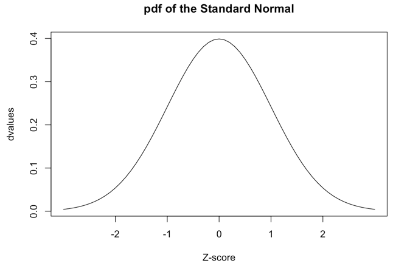

## Detour: probability distributions

- `pnorm()`: cumulative distribution function, the CDF evaluated at X.

```r
pnorm(0)
```

```
## [1] 0.5
```

```r
pnorm(1)
```

```
## [1] 0.8413447
```

```r
pnorm(-1)
```

```
## [1] 0.1586553
```

## Detour: probability distributions

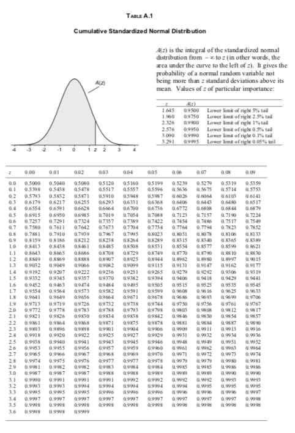

## Detour: probability distributions

- `qnorm()`: quantile function, the inverse CDF evaluated at a quantile.

```r
qnorm(c(0.05, 0.95))
```

```
## [1] -1.644854  1.644854
```

```r
qnorm(c(0.025, 0.975))
```

```
## [1] -1.959964  1.959964
```

```r
pnorm(qnorm(c(0.025, 0.975)))
```

```
## [1] 0.025 0.975
```

## Detour: probability distributions

- `rnorm()`: random sampling

```r
rnorm(1)
```

```
## [1] 1.512
```

```r
rnorm(5)
```

```
## [1]  0.00138504  0.59917440  0.86774686 -2.44397129  0.16783118
```

```r
rnorm(30)
```

```
##  [1]  1.4549136  0.3609099 -0.1118318  0.9593363  1.5520531 -0.9759057
##  [7]  0.5648750 -0.9046218 -1.1399470  1.4941778  0.3935411  0.1818493
## [13]  0.1096552 -0.7830749 -0.4851587 -0.2919613 -0.4830477 -0.1291324
## [19] -0.1278391 -1.0831788 -0.6827786  0.0151554 -0.2019645 -0.4117387
## [25]  1.0182614  1.1715970 -0.4483821  0.5020953  0.8392909 -0.2671491
```

## Best practices for functions

1. Keep your functions simple and short
2. Name functions well (verb_thing() is generally good), and document what they take as input and output
3. Check and debug your functions as you write them, not at the very end

## Want to learn more?

- [Functions Chapter](https://r4ds.had.co.nz/functions.html) in R for Data Science

[figure not shown]

## Recap

Today we:

- Introduced functions
- Discussed function arguments
- Reviewed probability distributions
- Gave a few pointers for writing your own functions

And that’s it for us this fall. Thanks for sticking with us these 5 weeks!

Find the workshop link on the course web page: http://harris-coding-lab.github.io

## Appendix: map() family of functions

Functions are powerful when `map()`ed to lists:

```r
shout_number <- function(number) {
  paste0("Number ", number, "!")
}
```

```r
numbers <- 1:10

# map returns a list the same length as numbers.
map(numbers, shout_number)
```

```
## [[1]]
## [1] "Number 1!"
##
## [[2]]
## [1] "Number 2!"
##
## [[3]]
## [1] "Number 3!"
##
## [[4]]
## [1] "Number 4!"
##
## [[5]]
## [1] "Number 5!"
##
## [[6]]
## [1] "Number 6!"
##
## [[7]]
## [1] "Number 7!"
##
## [[8]]
## [1] "Number 8!"
##
## [[9]]
## [1] "Number 9!"
##
## [[10]]
## [1] "Number 10!"
```

```r
#for (item in .x){
#  .f()
#}
```

## map() family of functions

The infixes influence the type of thing that is output:

```r
numbers <- 1:10

map_chr(numbers, shout_number)
```

```
##  [1] "Number 1!"  "Number 2!"  "Number 3!"  "Number 4!"  "Number 5!"
##  [6] "Number 6!"  "Number 7!"  "Number 8!"  "Number 9!"  "Number 10!"
```

## map() is nicer than apply()

```r
library(purrr)
numbers <- 1:10
map(numbers, shout_number)
```

```
## [[1]]
## [1] "Number 1!"
##
## [[2]]
## [1] "Number 2!"
##
## [[3]]
## [1] "Number 3!"
##
## [[4]]
## [1] "Number 4!"
##
## [[5]]
## [1] "Number 5!"
##
## [[6]]
## [1] "Number 6!"
##
## [[7]]
## [1] "Number 7!"
##
## [[8]]
## [1] "Number 8!"
##
## [[9]]
## [1] "Number 9!"
##
## [[10]]
## [1] "Number 10!"
```

## Another map() example

```r
calculate_sample_mean <- function(sample_size) {
  sample_mean <- mean(rnorm(sample_size))

  sample_mean
}

map_dbl(1:30, calculate_sample_mean)
```

```
##  [1] -0.770679703 -1.202518648  0.062975845  0.297993879  0.247681332
##  [6] -0.931632243  0.279796140 -0.352598283 -0.077761502  0.601494765
## [11]  0.086607873  0.040618739  0.285679945 -0.015948535 -0.234724128
## [16]  0.420278199 -0.166329965  0.179780769  0.101691417  0.021753537
## [21] -0.009521356 -0.237516848  0.114023466  0.045228329 -0.147090483
## [26]  0.108097499  0.225099659 -0.370085299  0.297717192 -0.153509261
```

This is doing the same work as our for-loop from last week.